# Fraud Detect

## Dataset

For this experiment we are using **TalkingData AdTracking Fraud Detection Challenge** located on [Kaggle](https://www.kaggle.com/c/talkingdata-adtracking-fraud-detection/data)

## Dataset Details

- ip: ip address of click.
- app: app id for marketing.
- device: device type id of user mobile phone (e.g., iphone 6 plus, iphone 7, huawei mate 7, etc.)
- os: os version id of user mobile phone
- channel: channel id of mobile ad publisher
- click_time: timestamp of click (UTC)
- attributed_time: if user download the app for after clicking an ad, this is the time of the app download
- is_attributed: the target that is to be predicted, indicating the app was downloaded

### Loading and exploring dataset

```r
df <- read_csv('train_sample.csv')
head(df)
```

```
## # A tibble: 6 x 8
##       ip   app device    os channel click_time          attributed_time
##    <dbl> <dbl>  <dbl> <dbl>   <dbl> <dttm>              <dttm>
## 1  87540    12      1    13     497 2017-11-07 09:30:38 NA
## 2 105560    25      1    17     259 2017-11-07 13:40:27 NA
## 3 101424    12      1    19     212 2017-11-07 18:05:24 NA
## 4  94584    13      1    13     477 2017-11-07 04:58:08 NA
## 5  68413    12      1     1     178 2017-11-09 09:00:09 NA
## 6  93663     3      1    17     115 2017-11-09 01:22:13 NA
## # … with 1 more variable: is_attributed <dbl>
```

checking if dataset has NA values

```r
any(is.na(df))
```

```
## [1] TRUE
```

before apply any the treatment in NA values on the dataset lets explore how NA values are distributed

```r
sum(is.na(df$ip))
```

```
## [1] 0
```

```r
sum(is.na(df$app))
```

```
## [1] 0
```

```r
sum(is.na(df$device))
```

```
## [1] 0
```

```r
sum(is.na(df$os))
```

```
## [1] 0
```

```r
sum(is.na(df$click_time))
```

```
## [1] 0
```

```r
sum(is.na(df$attributed_time))
```

```
## [1] 99773
```

```r
sum(is.na(df$is_attributed))
```

```
## [1] 0
```

as we can see, the unique field that have NA values is **attributed_time**

let’s understand what is the relationship between attribute_time and is_attributed (predict variable)

### Exploring data

#### plotting the relationship between attribute_time and is_attributed

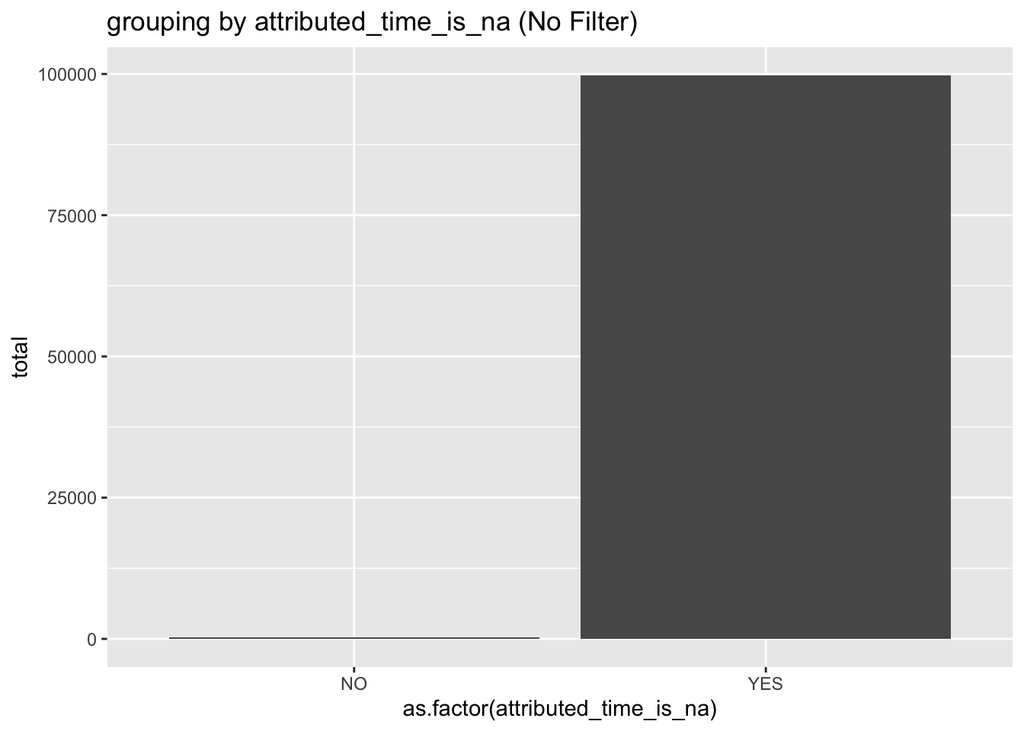

```r
df %>%
  mutate(attributed_time_is_na = ifelse(is.na(attributed_time) , 'YES', 'NO')) %>%
  group_by(attributed_time_is_na, is_attributed) %>%
  summarise(total = n())  %>%
  arrange(desc(total)) %>%
  ggplot(aes(x = as.factor(attributed_time_is_na), y = total)) +  geom_bar(stat='identity') + ggtitle('grouping by attributed_time_is_na (No Filter)')
```

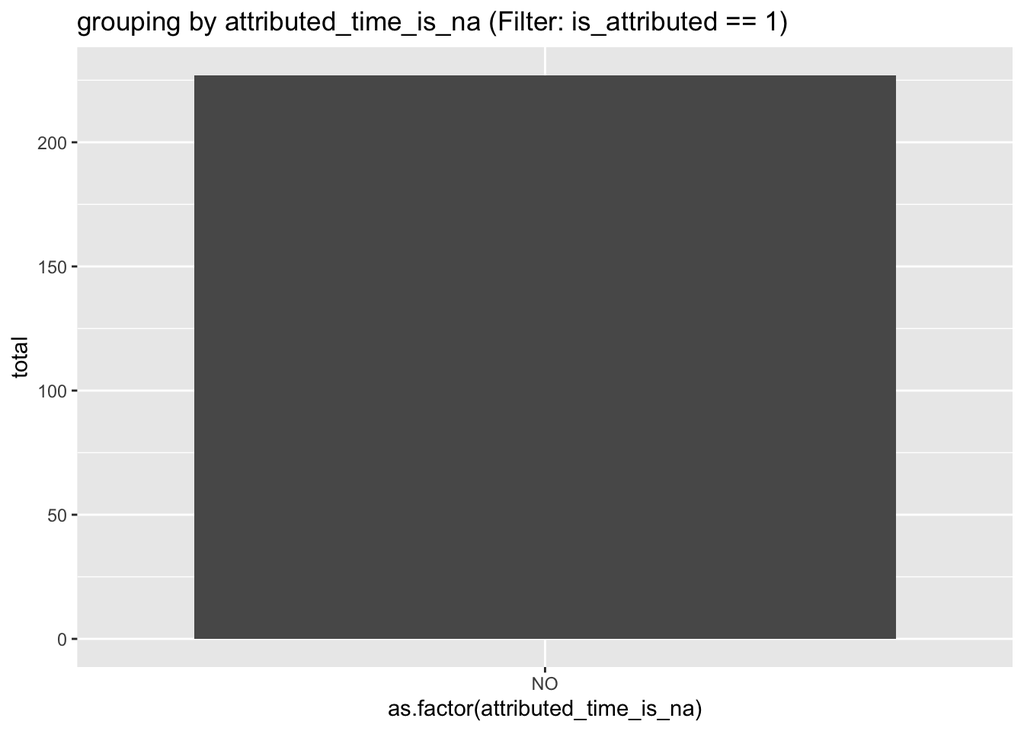

```r
df %>%
  filter(is_attributed == 1) %>%
  mutate(attributed_time_is_na = ifelse(is.na(attributed_time) , 'YES', 'NO')) %>%
  group_by(attributed_time_is_na, is_attributed) %>%
  summarise(total = n())  %>%
  arrange(desc(total)) %>%
  ggplot(aes(x = as.factor(attributed_time_is_na), y = total)) +  geom_bar(stat='identity') + ggtitle('grouping by attributed_time_is_na (Filter: is_attributed == 1)')
```

as we can see, where we apply filter **is_attributed == 1** the NA values tends to be zero this suggests that we can delete this column.

### Data Munging

- removing attributed_time
- extracting the day of the week and the hour of the column click_time
- creating the period column with the cut function passing the time as a parameter
- removing click_time

```r
df <- df %>%
  select(-c(attributed_time)) %>%
  mutate(weekday = Weekday(click_time), hour = hour(click_time)) %>%
  mutate(period = cut(hour, breaks = 4))  %>%
  select(-c(click_time, hour))
```

### Plotting data

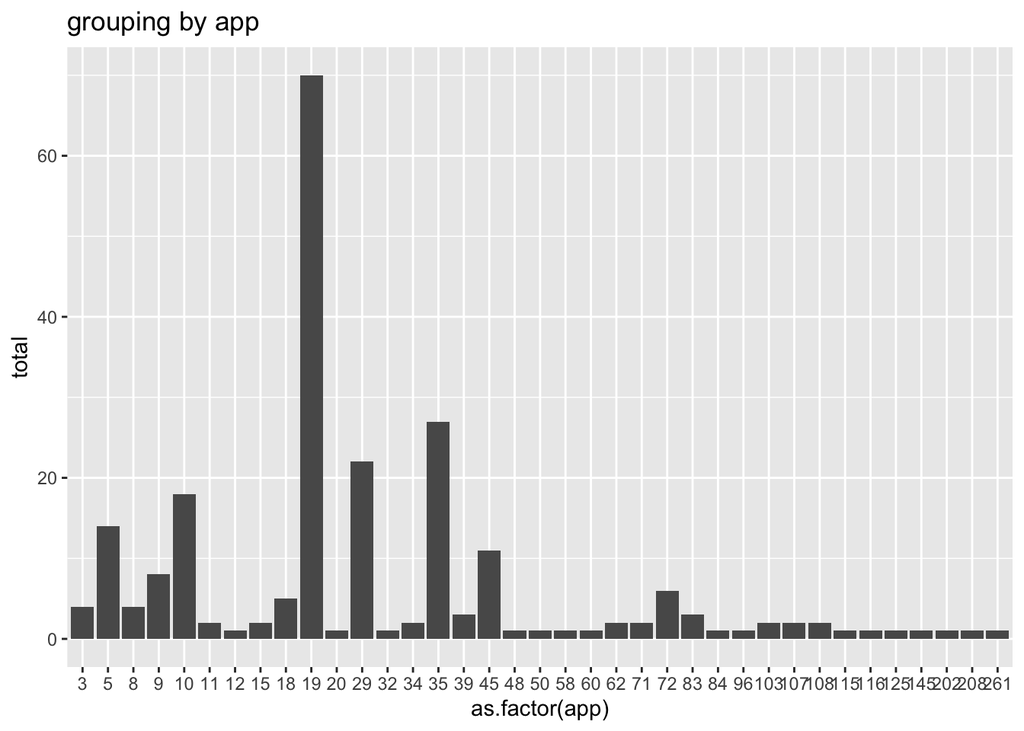

```r
df %>%
  filter(is_attributed == 1) %>%
  group_by(app) %>%
  summarise(total = n())  %>%
  arrange(desc(total)) %>%
  ggplot(aes(x = as.factor(app), y = total)) +  geom_bar(stat='identity') + ggtitle('grouping by app')
```

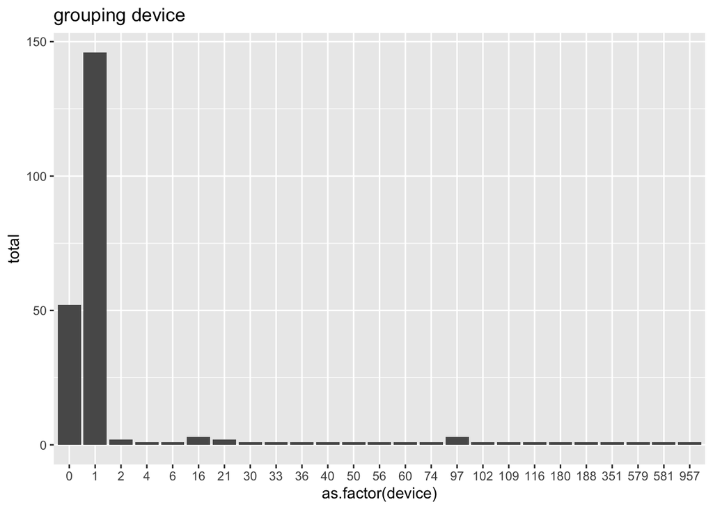

```r
df %>%
  filter(is_attributed == 1) %>%
  group_by(device) %>%
  summarise(total = n())  %>%
  arrange(desc(total)) %>%
  ggplot(aes(x = as.factor(device), y = total)) +  geom_bar(stat='identity') + ggtitle('grouping device')
```

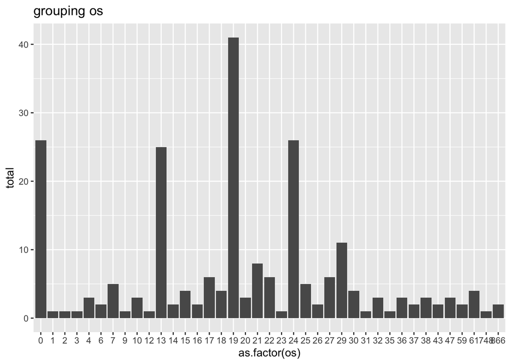

```r
df %>%
  filter(is_attributed == 1) %>%
  group_by(os) %>%
  summarise(total = n())  %>%
  arrange(desc(total)) %>%
  ggplot(aes(x = as.factor(os), y = total)) +  geom_bar(stat='identity') + ggtitle('grouping os')
```

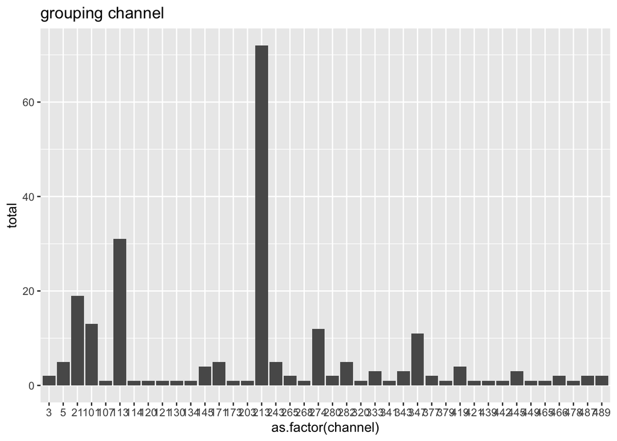

```r
df %>%
  filter(is_attributed == 1) %>%
  group_by(channel) %>%
  summarise(total = n())  %>%
  arrange(desc(total)) %>%
  ggplot(aes(x = as.factor(channel), y = total)) +  geom_bar(stat='identity') + ggtitle('grouping channel')
```

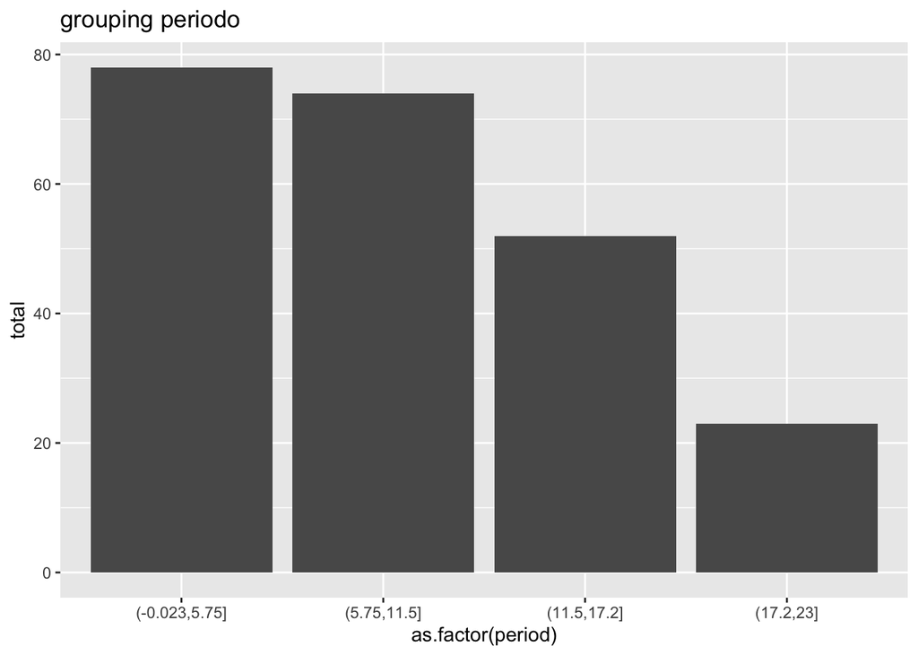

```r
df %>%
  filter(is_attributed == 1) %>%
  group_by(period) %>%
  summarise(total = n())  %>%
  arrange(desc(period)) %>%
  ggplot(aes(x = as.factor(period), y = total)) +  geom_bar(stat='identity') + ggtitle('grouping periodo')
```

### make columns categorical

```r
categorical.vars <- c('app', 'device', 'os', 'channel', 'is_attributed', 'weekday', 'ip')

to.factors <- function(df, variables){
  for (variable in variables){
    df[[variable]] <- as.factor(df[[variable]])
  }
  return(df)
}

# apply to.factors function
df <- to.factors(df = df, variables = categorical.vars)
```

### check if the dataset is unbalanced

```r
prop.table(table(df$is_attributed))
```

```
##
##       0       1
## 0.99773 0.00227
```

as we can see, the dataset is **unbalanced**

### using SMOTE to balance the dataset

```r
df <- as.data.frame(df)
df <- SMOTE(is_attributed ~. ,df, perc.over = 100,perc.under=200)
prop.table(table(df$is_attributed))
```

```
##
##   0   1
## 0.5 0.5
```

### splitting data

```r
df[,'index'] <- ifelse(runif(nrow(df)) < 0.8,1,0)
trainset <- df[df$index==1,]
testset <- df[df$index==0,]

trainColNum <- grep('index', names(trainset))
trainset <- trainset[,-trainColNum]
testset <- testset[,-trainColNum]

nrow(trainset)
```

```
## [1] 715
```

```r
nrow(testset)
```

```
## [1] 193
```

### training using SVM

```r
model_svm <- svm(is_attributed ~ ., data = trainset, kernel = "linear", cost = 2)

summary(model_svm)
```

```
##
## Call:
## svm(formula = is_attributed ~ ., data = trainset, kernel = "linear",
##     cost = 2)
##
##
## Parameters:
##    SVM-Type:  C-classification
##  SVM-Kernel:  linear
##        cost:  2
##
## Number of Support Vectors:  302
##
##  ( 190 112 )
##
##
## Number of Classes:  2
##
## Levels:
##  0 1
```

### making predictions

```r
predict <- predict(model_svm, newdata = testset)
```

### checking confusion matrix

```r
table(testset$is_attributed, predict)
```

```
##    predict
##      0  1
##   0 85  6
##   1  5 97
```

### checking % of hits

```r
mean(testset$is_attributed == predict) * 100
```

```
## [1] 94.30052
```

### Plotting ROC Curve

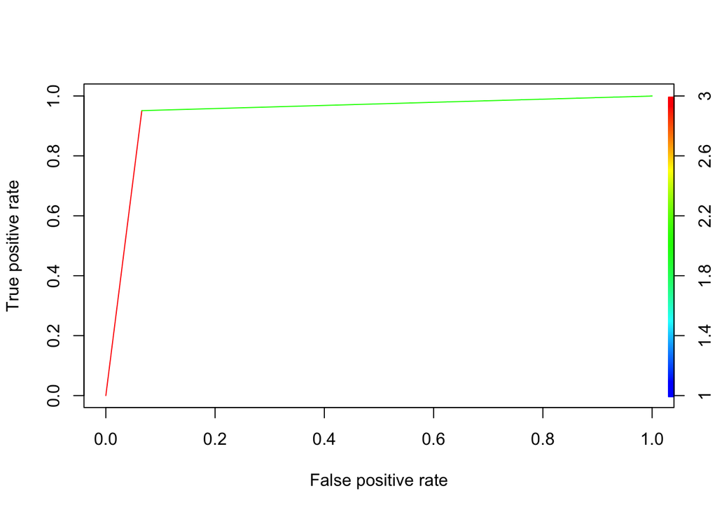

```r
pred <- prediction(as.numeric(predict), testset$is_attributed)
perf <- performance(pred,"tpr","fpr")
plot(perf,colorize=TRUE)
```